# Model evaluation: sensitivity and elasticity analysis for common bottlenose dolphins in Barataria Bay

# Preamble

This is an Electronic Supplement to the manuscript Schwacke et al. 2022. Modeling population effects of the Deepwater Horizon oil spill on a long-lived species. $Conservation~Biology$ 36:e13878 DOI: https://doi.org/10.1111/cobi.13878

The master file containing links to all supplementary files related to this paper is BND_Electronic Supplements master file.

If you make use of any of this material in your work, it would be appreciated if you would contact Tiago Marques to let him know.

# Introduction

This working document describes how the injury results reported depend on the different population dynamics model parameters considered. All the parameters have uncertainty associated with them and it is only natural to ask what would change in the reported values for the injury metrics if the input parameters changed accordingly. We have 3 injury metrics:

- lost cetacean years (LCY),
- maximum proportional decrease (MPD), and
- years to recovery (YTR).

To contrast the two, imagine two model parameters for which uncertainty on inputs produces the same moderate level of uncertainty on the estimate of an injury metric. In one case this might be because there is considerable uncertainty on the input (i.e., the parameter is not known at all precisely) combined with low elasticity (i.e., little effect of this uncertainty on the injury metric); in the second case this might be because there is little uncertainty on the input combined with high elasticity. Undertaking both an uncertainty and an elasticity analysis allows us to distinguish between these scenarios.

The analyses reported in this document are based on files produced by sourcing the file `Run_BND_Ttru_PopSimsSensitivity`. That source file produces a result file for each parameter that we then post-process here to obtain both uncertainty and elasticity values.

# The model parameters

We provide a complete list of the quantities/parameters/statistics considered in the BND BB population dynamics model, that might therefore have an impact in the injury metrics:

- Derived from the SECR capture recapture study reported by Glennie et al. 2021, with distributions available via parametric bootstrap resampling; see also BND_InitialPopulation for details.
  - $N_0$: initial population size
  - $S_1$: post oil spill survival
- Based on the Expert Elicitation exercise, see SI section on Expert Elicitation exercise, for details
  - $\rho$: density dependence shape parameter; modeled as a shifted gamma distribution
  - $P_{recovery}$: proportion of exposed animals that recover to baseline survival and fecundity levels within their lifetime; modeled as a shifted beta distribution
- Based on earlier published work, see SI, Table S2.1 - Input parameters for population model, for additional source details
  - $S_m$ and $S_f$: a vector of age and sex dependent survival for males and females, based on the Siler model parameters, see SurvivalReduction for details
  - $ASM$: age of sexual maturity; modeled as a gamma distribution; see AgeOfSexualMaturity for details.
  - $F_{max}$: maximum fecundity - modeled as a beta-PERT distribution
  - $F_{nom}$: nominal fecundity - modeled as a beta-PERT distribution
  - $R_{baseline}$: baseline reproductive success - modeled as beta distribution
  - $R_1$: post-spill reproductive success - modeled as beta distribution
- Based on unpublished data
  - $P_{marked}$: a vector of probabilities of an animal being marked as a function of age, see SurvivalReduction for details

All these quantities and their respective distributions/parameters are provided in file `SpeciesDefinitionFile.xlsx`.

# Sensitivity Analysis

We want to estimate the sensitivity to the 11 parameters defined above. We have run 1000 iterations for each parameter to evaluate sensitivity, and then we derive the elasticity by post-processing these runs to evaluate how the injury metric changes by changing the parameter in the vicinity of its mean value. We adress these in turn in the follwoing two sub-sections.

## Uncertainty

Consider a given parameter $K$. Consider $I$ as an example injury metric. The mean $I$ from the 1000 observations of a given injury metric is $\bar{I}$. We represent the $PC^k(I)$ as the proportional change in $I$ for parameter $K$.

We have represented in the plot below, for each injury metric and each parameter, the corresponding proportional change, in particular, the median, 2.5 and 97.5 percentiles of the distribution of proportional changes, across the 1000 uncertainty iterations for each parameter $K$

$PC^K_{j}(I)=\frac{I^K_{j}-\bar{I}}{\bar{I}},~j=1,2,...,1000$

where, for each parameter $K$ for which uncertainty is being evaluated, $K$ is allowed to change but all other parameters are kept at their nominal value.

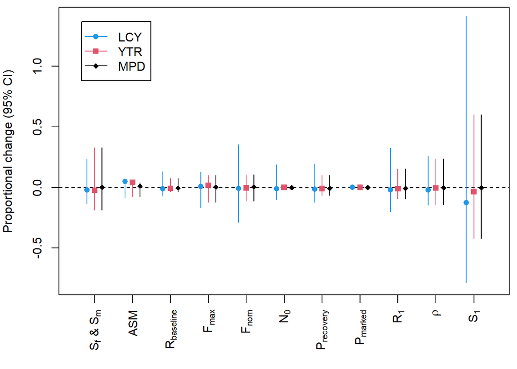

```r
# BB BND
# number of iterations used in the sensitivity analysis
runs4Sens <- 1000
patt <- paste0(runs4Sens, "Sens")
# get files names
files <- list.files(path = "InOutBySp/Bottlenose_dolphin_BB", pattern = patt)
# check how many files
nfiles <- length(files)
# set up number of plots in figure
par(mfrow = c(1, 1), mar = c(5, 4, 0.5, 0.5))
plot(c(0.5, 11.5), c(-0.8, 1.4), type = "n", xlab = "", main = "", xaxt = "n", ylab = "Proportional change (95% CI)")
abline(h = 0, lty = 2)
for (i in 1:nfiles) {
  # for each parameter
  # load the sensitivity results
  # this loads up a workspace that includes object injury
  # a 3 column (one per injury metric) by runs4Sens iterations data.frame
  ## a 3 column (one per injury metric) by nsims iterations data.frame
  ## LT: What is nsims?  You have runs4Sens defined above - is that the same thing?
  ## LT: So far as I can see, run4Sens is not used in any case, except to define the patt
  ## LT: name.  So perhaps the code would have better long-term robustness if you did away
  ## LT: with that, otherwise you're liable to change the number of sensitivity simulations in
  ## LT: whatever file it is that generates those, and then forget to change it here.
  ## LT: In general, constants should only be defined in one location!
  load(paste0("InOutBySp/Bottlenose_dolphin_BB/", files[i]))
  # get name of parameter in files[i]
  str <- files[i]
  # parameter name start
  startp <- str_locate(string = str, pattern = "Sens")[2] + 1
  # parameters name end
  endp <- str_locate(string = str, pattern = ".RD")[1] - 1
  par.name <- substr(str, startp, endp)
  # scale the injury by subtracting mean injury for each injury metric
  sinjury <- scale(injury, scale = FALSE)
  # divide by mean for each injury metric
  sinjury[, 1] <- sinjury[, 1] / mean(injury[, 1], na.rm = TRUE)
  sinjury[, 2] <- sinjury[, 2] / mean(injury[, 2], na.rm = TRUE)
  sinjury[, 3] <- sinjury[, 3] / mean(injury[, 3], na.rm = TRUE)
  # plot results
  qsinjury <- apply(sinjury, 2, quantile, probs = c(0.025, 0.5, 0.975), na.rm = TRUE)
  segments(i - 0.2, qsinjury[1, 1], i - 0.2, qsinjury[3, 1], col = 4)
  segments(i, qsinjury[1, 2], i, qsinjury[3, 2], col = 2)
  segments(i + 0.2, qsinjury[1, 2], i + 0.2, qsinjury[3, 2], col = 1)
  points(c(i - 0.2, i, i + 0.2), qsinjury[2, ], col = c(4, 2, 1), pch = c(16, 15, 18))
  label <- par.name
  if (par.name == "N0") label <- expression(N[0])
  if (par.name == "br") label <- expression(R[baseline])
  if (par.name == "por") label <- expression(R[1])
  if (par.name == "rho") label <- expression(rho)
  if (par.name == "per") label <- expression(P[recovery])
  if (par.name == "spos") label <- expression(S[1])
  if (par.name == "Fmax") label <- expression(F[max])
  if (par.name == "Fnom") label <- expression(F[nom])
  if (par.name == "ascS") label <- expression(paste(S[f, j], " & ", S[m, j]))
  if (par.name == "PM") label <- expression(P[marked])
  axis(side = 1, at = i, labels = label, las = 2)
  legend("topleft", inset = 0.05, legend = names(injury), col = c(4, 2, 1), lty = 1, pch = c(16, 15, 18))
}
```

## Elasticity

In this analysis we used the values obtained under the uncertainty analysis - see previous sub-section - to model the percentage change in the 3 injury metrics (Lost Cetacean Years LCY, Years to Recovery YTR and Maximum Proportional Decrease MPD) as a function of a unit percentage change in the different input parameters. To do so, we used a generalized additive model (GAM), Gaussian response, and identity link. The reported results are virtually insensitive to the specific model chosen since the relations are all extremely smooth where it matters to evaluate elasticity, which is in the vicinity of the point estimate (here we considered the mean) of the parameter being evaluated. For a couple of injury metrics and parameters combinations the fit is far from ideal, in particular for YTR, but since this happens mostly when the elasticity is extremely small the effects are negligible. These problems originate because we are approximating change in a discrete injury metric (YTR) with a continuous function.

The corresponding results are shown below, where we report the percentage change on the 3 injury metrics when each parameter is varied by 1% around the mean (i.e. increased or decreased by 0.5%), while all the other parameters are kept at their mean value.

We first define an object to hold the elasticity measure for each parameter.

```r
metrics <- c("LCY", "YTR", "MPD")
nmetrics <- length(metrics)
elasticity <- data.frame(parID = 1:11, parameter = NA, LCY = NA, YTR = NA, MPD = NA)
```

Here we calculate the injury metric percent change for each change in 1% on each of the 11 parameters. The next couple of code chunks do not output plots by default, but by removing the chunk options `results='hide',fig.show='hide'` the .Rmd will lead the code to show plots that provide insights to what is going on under the hood.

Note that for two of the inputs to the model are not scalars, namely

- $S_{f,j}$ and $S_{m,j}$, and
- $P_{marked}$,

Since there is no univariate quantity to consider that the injury metric depends on the above procedure needs an extension, where we use a univariate measure to represent these quantities. We considered the weighted (weighted by the proportion in each age and sex class) average survival, which we refer to as `meanSiler` (we also look at these means by sex, namely `meanSilerF` for females and `meanSilerM` for males), and the average $P_{marked}$, that we refer to as `paPM`, as the corresponding univariate quantities to evaluate the injury metrics against. Note that because the same mean value can be obtained with different combinations of the vectors, and different combinations of the corresponding vectors will have different impacts on the injury metric, this will lead to noise around the relationship we are trying to estimate.

```
## Elasticity analysis for Ttrusimres1000SensascS.RData
```

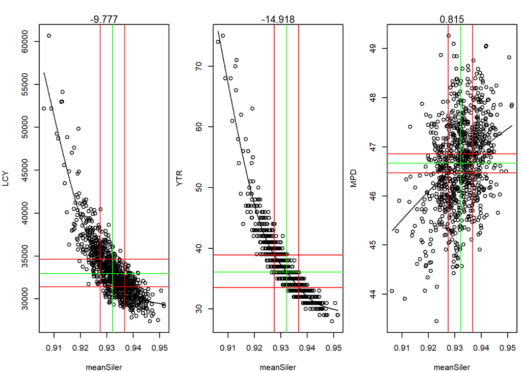

```
## Elasticity analysis for Ttrusimres1000SensASM.RData
```

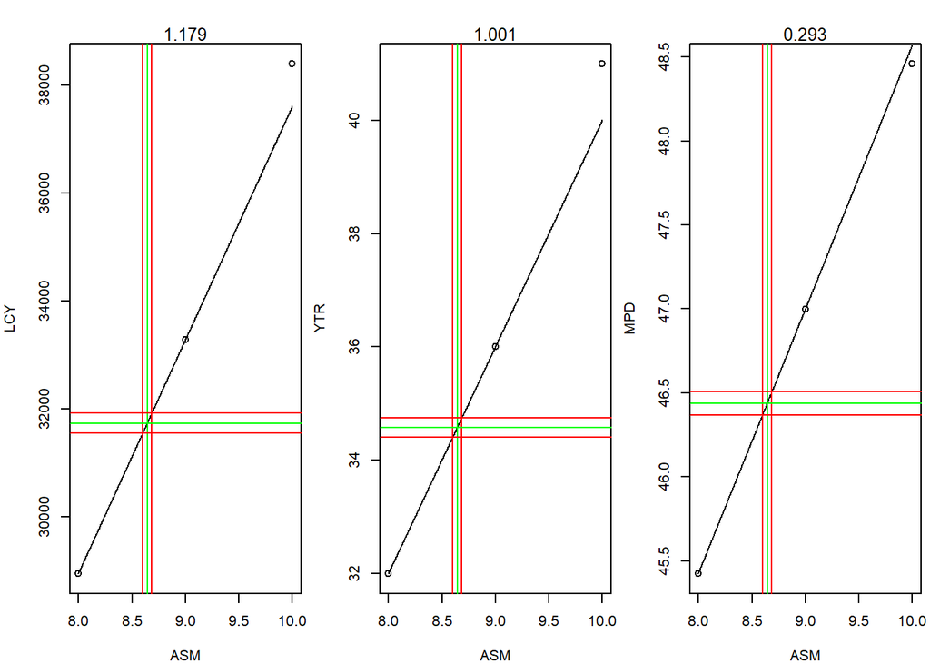

```
## Elasticity analysis for Ttrusimres1000Sensbr.RData
```

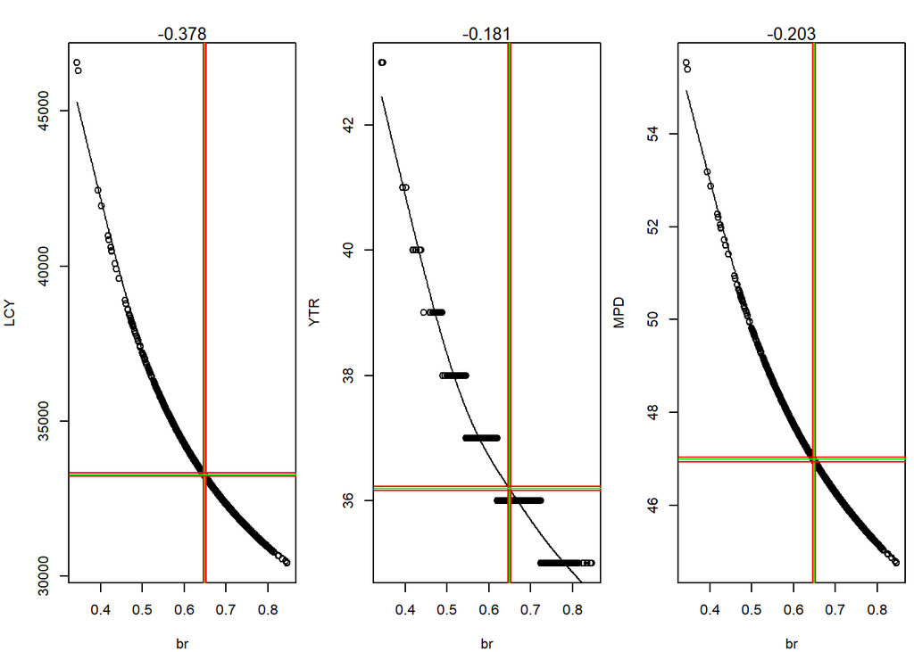

```
## Elasticity analysis for Ttrusimres1000SensFmax.RData
```

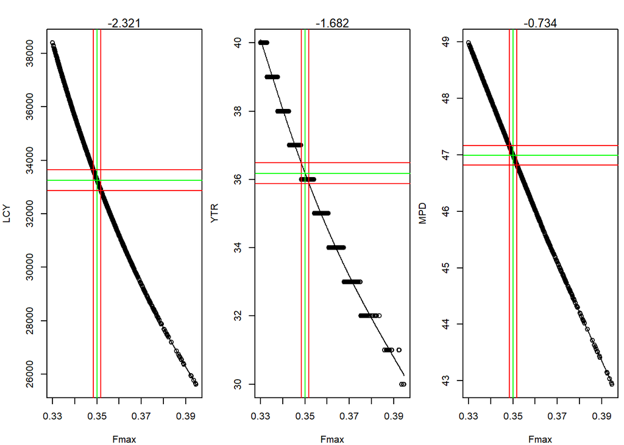

```
## Elasticity analysis for Ttrusimres1000SensFnom.RData
```

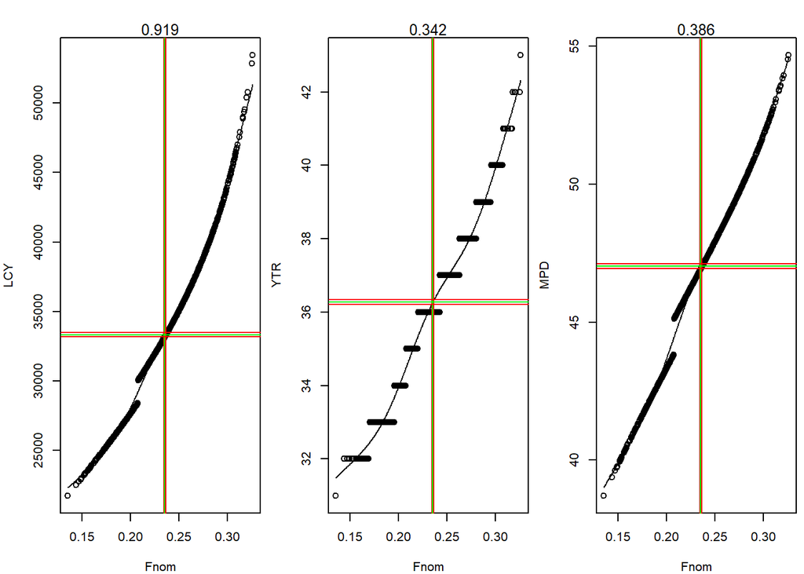

```
## Elasticity analysis for Ttrusimres1000SensN0.RData
```

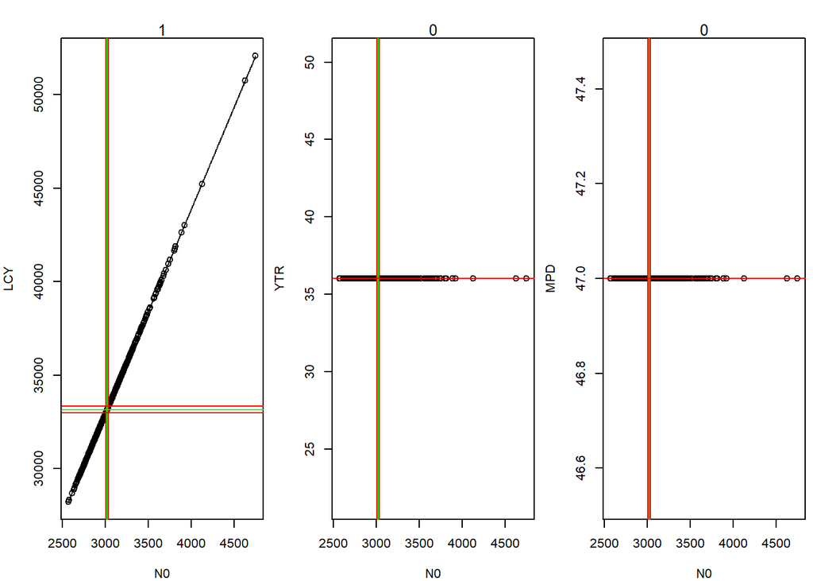

```
## Elasticity analysis for Ttrusimres1000Sensper.RData
```

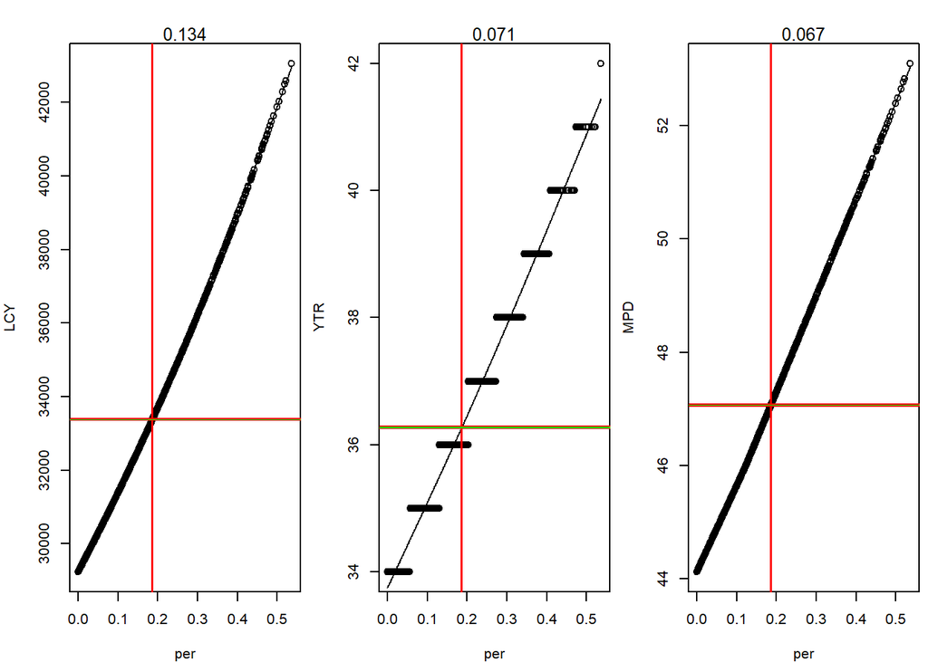

```
## Elasticity analysis for Ttrusimres1000SensPM.RData
```

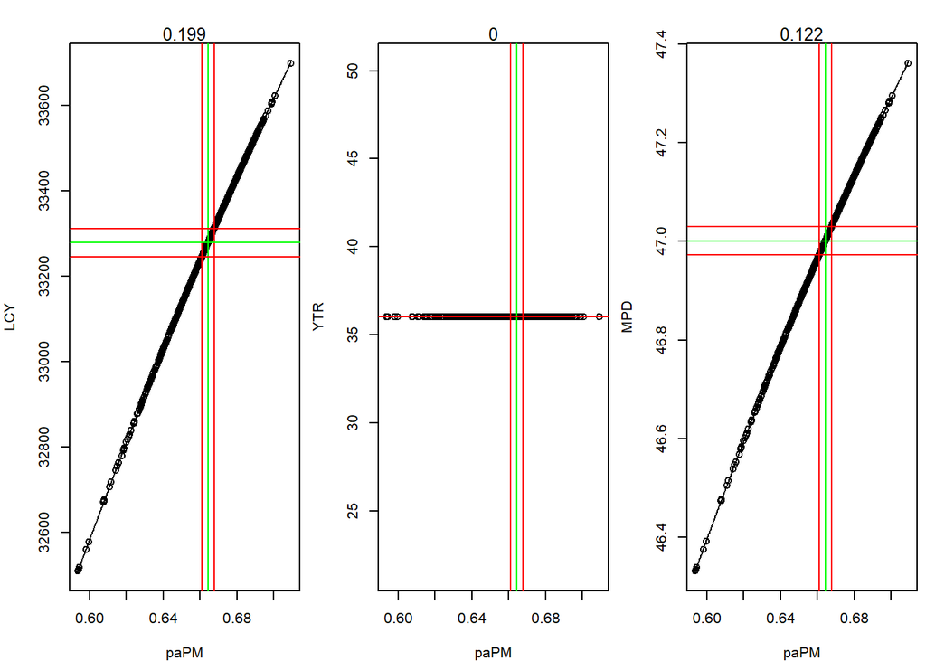

```
## Elasticity analysis for Ttrusimres1000Senspor.RData
```

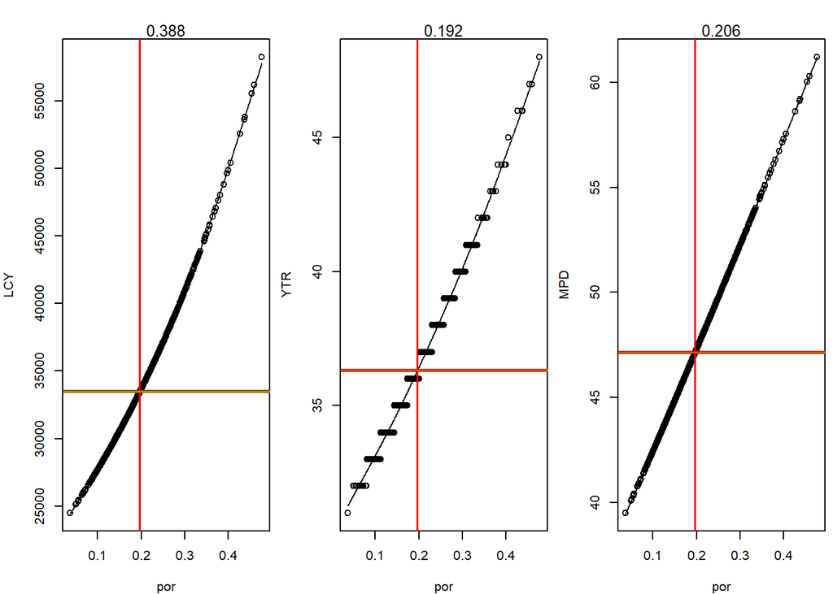

```
## Elasticity analysis for Ttrusimres1000Sensrho.RData
```

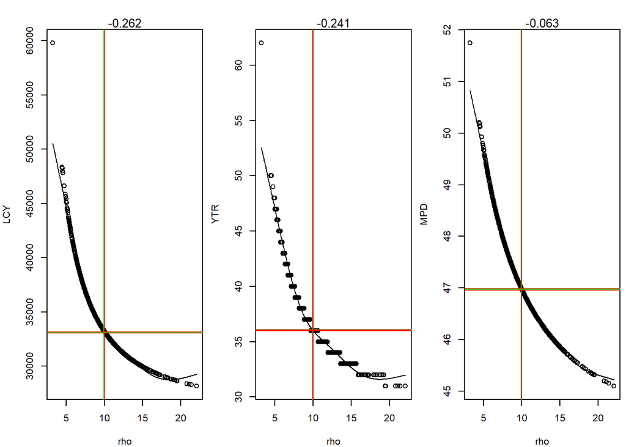

```
## Elasticity analysis for Ttrusimres1000Sensspos.RData
```

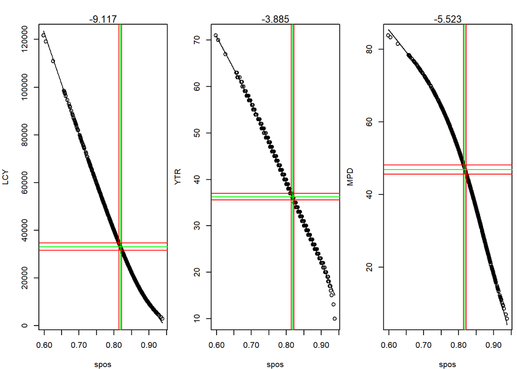

````r
#```{r, results='hide', fig.show='hide'}
# set up number of plots in figure
par(mfrow = c(1, 3), mar = c(4, 4, 2.5, 0.5))
for (i in 1:nfiles) {
  cat(paste0("Elasticity analysis for ", files[i]))
  # this loads up a workspace that includes object injury
  # a 3 column (one per injury metric) by number of iterations data.frame
  load(paste0("InOutBySp/Bottlenose_dolphin_BB/", files[i]))
  # for each parameter
  # get name of parameter in files[i]
  str <- files[i]
  # parameter name start
  startp <- str_locate(string = str, pattern = "Sens")[2] + 1
  # parameters name end
  endp <- str_locate(string = str, pattern = ".RD")[1] - 1
  par.name <- substr(str, startp, endp)
  elasticity$parameter[i] <- par.name
  # do not process the file for proportion exposed - a null control
  #* TAM*: delete
  if (par.name == "pe") next
  # select the parameter being evaluated - change parameter name later to avoid this tweak
  #if (par.name == "ascS") par.name <- "ascS"
  #if (par.name == "ascS") par.name <- "meanS"
  if (par.name == "ascS") par.name <- "meanSiler"
  if (par.name == "PM") par.name <- "paPM"
  p2spar <- eval(parse(text = paste0("pars2save$", par.name)))
  for (k in 1:nmetrics) {
    # select the k_th injury (k = 1,2,3)
    inj <- eval(parse(text = paste0("injury$", metrics[k])))
    # plot results
    plot(p2spar, inj, xlab = par.name, ylab = metrics[k])
    dat4mod <- data.frame(par = p2spar, inj = injury[, k])
    # if there are not enough unique values of the parameter being evaluated
    # only happens if the parameter is ASM (2-3 unique values)
    # force a linear model fit, else a relatively inflexible GAM
    if (length(unique(inj))<=3) {
      mod <- lm(inj ~ par, data = dat4mod)
    } else {
      mod <- gam(inj ~ s(par,k=5), data = dat4mod)
    }
    seqpars <- seq(min(p2spar), max(p2spar), length = 500)
    preds <- predict(mod, newdata = data.frame(par = seqpars), type = "response")
    # check model adequate for predictions by plotting relationship and addinmodel on top
    lines(seqpars, preds)
    mpar <- mean(p2spar)
    delta <- c(0.995, 1, 1.005)
    nd <- data.frame(par = mpar * delta)
    preds <- predict(mod, newdata = nd, type = "response")
    m.metrics <- mean(inj)
    abline(v = c(mpar * delta), col = c("red", "green", "red"))
    abline(h = c(preds), col = c("red", "green", "red"))
    # calculate elasticity measure for the m_th parameter and k_th injury metric
    elas <- 100 * (preds[3] - preds[1]) / preds[2]
    # save it in the right slot
    elasticity[i, 3 + k] <- elas
    # add number to top of the plot
    mtext(text = round(elas,3), side = 3, cex = 0.8)
  }
}
````

We represent the elasticity measures per parameter here:

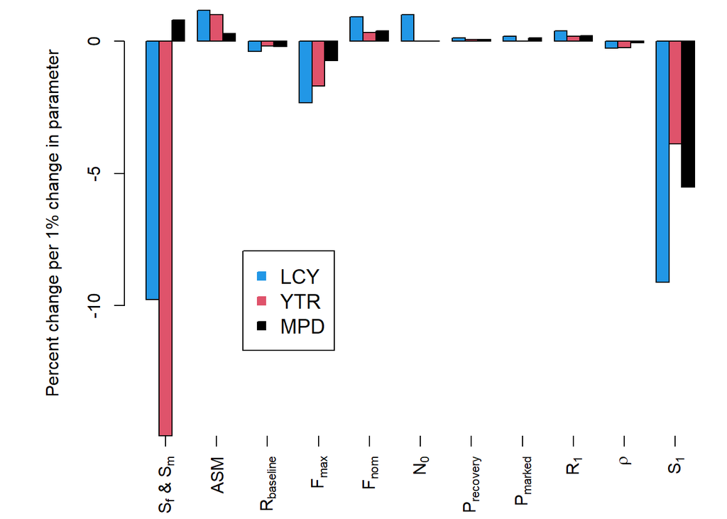

```r
par(mfrow = c(1, 1), mar = c(4, 6, 0.5, 0.5))
barplot(t(as.matrix(elasticity[, 4:6])), col = c(4, 2, 1), beside = TRUE, ylab = "Percent change per 1% change in parameter")
for (i in 1:nrow(elasticity)) {
  # set reasonable label
  label <- switch(elasticity$parameter[i],
    ASM = "ASM",
    N0 = expression(N[0]),
    br = expression(R[baseline]),
    por = expression(R[1]),
    rho = expression(rho),
    per = expression(P[recovery]),
    spos = expression(S[1]),
    Fmax = expression(F[max]),
    Fnom = expression(F[nom]),
    ascS = expression(paste(S[f, j], " & ", S[m, j])),
    PM = expression(P[marked])
  )
  axis(side = 1, at = 2.5 + (i - 1) * 4, labels = label, las = 2)
}
legend("bottomleft", col = c(4, 2, 1), pt.bg = c(4, 2, 1), legend = metrics, inset = 0.2, cex = 1.2, pch = 22)
```

To further understand elasticity it might be useful to represent population trajectories under different extreme realizations of a given parameter. As an example, we show said trajectories for the mean Siler survival (i.e. mean Survival weighted for the proportion in each age class and sex, but not weighted for the proportion marked) below:

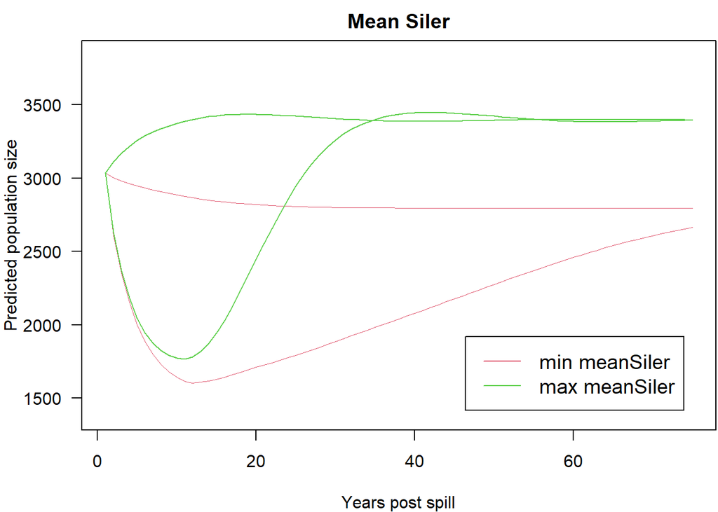

```r
load("InOutBySp/Bottlenose_dolphin_BB/Ttrusimres1000SensascS.RData")
sr <- simres
par(mfrow=c(1,1),mar = c(4, 4, 2, 0.1))
nyears <- dim(sr)[2]
nsims <- dim(sr)[3]
ylims <- c(min(c(colSums(sr[, , 1:nsims, 2]), colSums(sr[, , 1:nsims, 1])))*0.9, max(c(colSums(sr[, , 1:nsims, 2]), colSums(sr[, , 1:nsims, 1])))*1.1)
plot(colSums(sr[, , 1, 2]), type = "n", ylim = ylims, xlab = "Years post spill", ylab = "Predicted population size", las = 1,main="Mean Siler")
iMAX <- which(pars2save$meanSiler==max(pars2save$meanSiler))[1]
iMIN <- which(pars2save$meanSiler==min(pars2save$meanSiler))[1]
# baseline under minimum value for parameter
lines(colSums(sr[, , iMIN, 2]), type = "l", lwd = 0.7, col = 2)
# baseline under maximum value for parameter
lines(colSums(sr[, , iMAX, 2]), type = "l", lwd = 1, col = 3)
# under oil minimum value for parameter
lines(colSums(sr[, , iMIN, 1]), type = "l", lwd = 0.7, col = 2)
# under oil maximum value for parameter
lines(colSums(sr[, , iMAX, 1]), type = "l", lwd = 1, col = 3)
# add a legend
legend("bottomright",inset=0.05,cex=1.2,col=2:3,lty=1,legend=c("min meanSiler","max meanSiler"))
```

In general terms, for each of the parameters, the relationship between what are the relative impacts in terms of uncertainty also reflect in similar patterns for elasticity. A noticeable difference is perhaps what happens for baseline survival, where the effect on the MPD presents an opposing pattern in elasticity. This pattern happens because while both YTR and LCY are naturally affected by the lower survival inducing longer recoveries, and hence much larger values for those injury metrics under low survival, the MPD is actually larger under high survival because the baseline scenario population size increases much more compared to post-spill scenario under the same conditions.

One might also want to identify why there is such variability in the MPD when considering the meanSiler. It is perhaps unanticipated why not so different “average” meanSiler survivals could lead to MPD ranging from 44% to 50%. Visualizing those below show us that in fact the trajectories are somewhat different. But if the meanSiler is similar, what causes the difference?

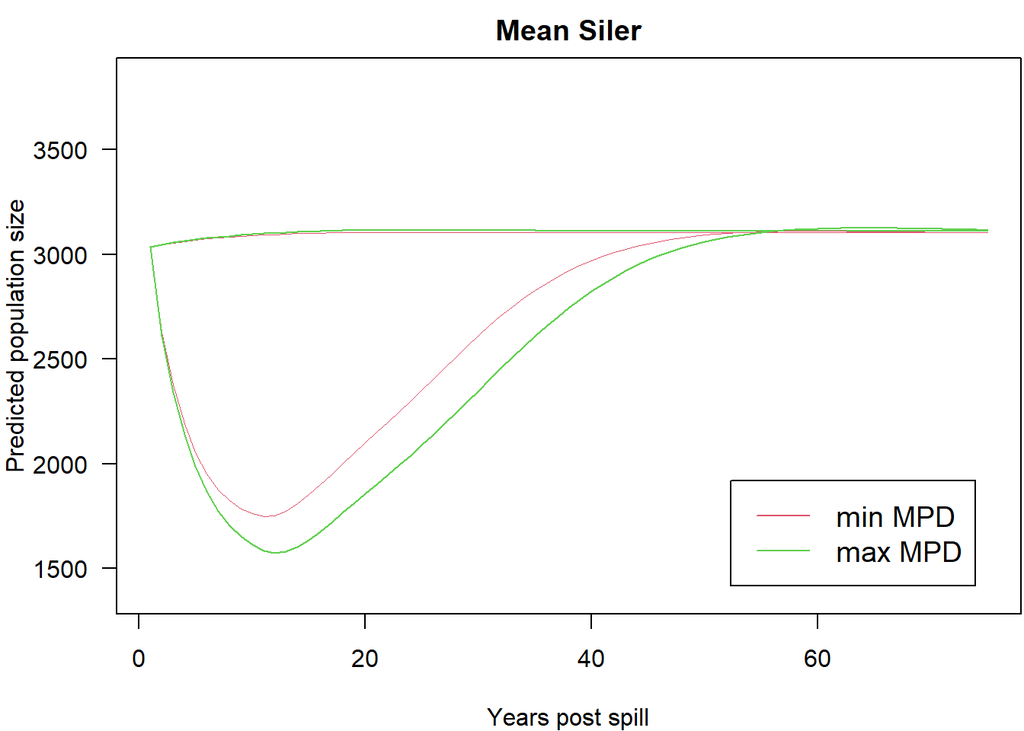

```r
load("InOutBySp/Bottlenose_dolphin_BB/Ttrusimres1000SensascS.RData")
sr <- simres
par(mfrow=c(1,1),mar = c(4, 4, 2, 0.1))
nyears <- dim(sr)[2]
nsims <- dim(sr)[3]
ylims <- c(min(c(colSums(sr[, , 1:nsims, 2]), colSums(sr[, , 1:nsims, 1])))*0.9, max(c(colSums(sr[, , 1:nsims, 2]), colSums(sr[, , 1:nsims, 1])))*1.1)
plot(colSums(sr[, , 1, 2]), type = "n", ylim = ylims, xlab = "Years post spill", ylab = "Predicted population size", las = 1,main="Mean Siler")
iMAX <- which(injury$MPD==max(injury$MPD))[1]
iMIN <- which(injury$MPD==min(injury$MPD))[1]
# baseline under minimum value for parameter
lines(colSums(sr[, , iMIN, 2]), type = "l", lwd = 0.7, col = 2)
# baseline under maximum value for parameter
lines(colSums(sr[, , iMAX, 2]), type = "l", lwd = 1, col = 3)
# under oil minimum value for parameter
lines(colSums(sr[, , iMIN, 1]), type = "l", lwd = 0.7, col = 2)
# under oil maximum value for parameter
lines(colSums(sr[, , iMAX, 1]), type = "l", lwd = 1, col = 3)
# add a legend
legend("bottomright",inset=0.05,cex=1.2,col=2:3,lty=1,legend=c("min MPD","max MPD"))
```

Do we get a hint of what is going on if we plot these injury metrics against survival separated by sex?

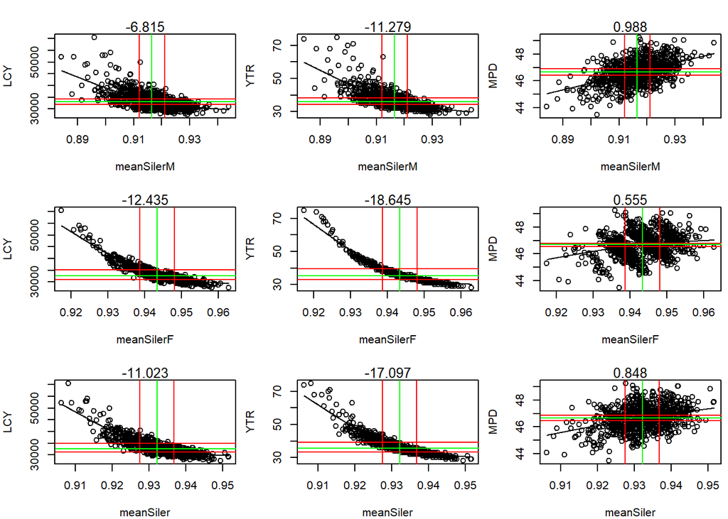

```r
par(mfrow = c(3, 3), mar = c(4, 4, 2.5, 0.5))
#for each possible x-axis value to evaluate elasticity against in the case of baseline survival
par.names<-c("meanSilerM","meanSilerF","meanSiler")
for(s in 1:3){
  par.name <- par.names[s]
  p2spar <- eval(parse(text = paste0("pars2save$", par.name)))
  for (k in 1:nmetrics) {
    # select the k_th injury (k = 1,2,3)
    inj <- eval(parse(text = paste0("injury$", metrics[k])))
    # plot results
    plot(p2spar, inj, xlab = par.name, ylab = metrics[k])
    dat4mod <- data.frame(par = p2spar, inj = injury[, k])
    # if there are not enough unique values of the parameter being evaluated
    # only happens if the parameter is ASM (2 unique values)
    # force a linear model fit, else a relatively inflexible GAM
    if (length(unique(inj))<=2) {
      mod <- lm(inj ~ par, data = dat4mod)
    } else {
      mod <- gam(inj ~ s(par, k = 3), data = dat4mod)
    }
    seqpars <- seq(min(p2spar), max(p2spar), length = 500)
    preds <- predict(mod, newdata = data.frame(par = seqpars), type = "response")
    # check model adequate for predictions by plotting relationship and addinmodel on top
    lines(seqpars, preds)
    mpar <- mean(p2spar)
    delta <- c(0.995, 1, 1.005)
    nd <- data.frame(par = mpar * delta)
    preds <- predict(mod, newdata = nd, type = "response")
    m.metrics <- mean(inj)
    abline(v = c(mpar * delta), col = c("red", "green", "red"))
    abline(h = c(preds), col = c("red", "green", "red"))
    # calculate elasticity measure for the m_th parameter and k_th injury metric
    elas <- 100 * (preds[3] - preds[1]) / preds[2]
    # save it in the right slot
    mtext(text = round(elas,3), side = 3, cex = 0.8)
  }
}
```

We can get a feeling for how female survival seems to be more relevant for the injury metrics if we investigate what induces the larger differences in MPD. Looking at the female and male survivals for the two iterations that lead to the largest differences in MPD, even though they have very similar meanSiler survivals of 0.923 (minimum MPD) and 0.928 (maximum MPD).

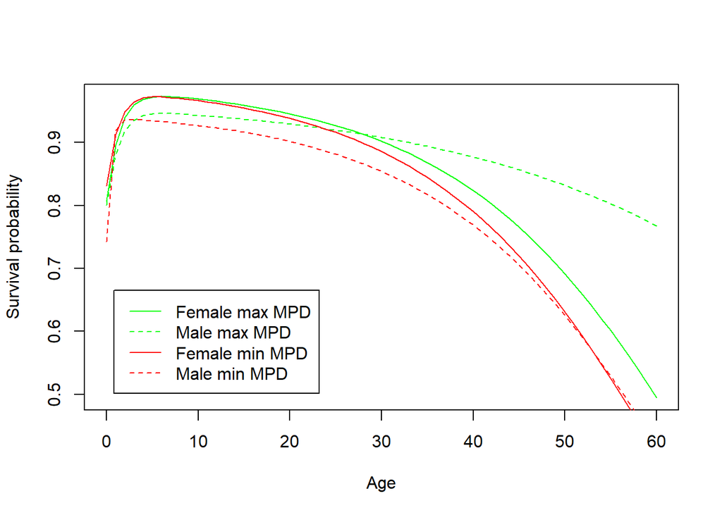

```r
source("Functions/SilerFuns.R") # Siler model functions are here
naBND <- 61 # number of age classes for BND
agesBND <- 0:(naBND - 1)
  #--------------------------------------------------------------------------
  # Survival
  #--------------------------------------------------------------------------
  # reading in Siler parameters, for male and female BNDs
  # These files were provided by LS via email on the Fri 5/22/2020 4:10 PM
  pf <- read.csv("InputFiles/var_female 15May2020.csv")
  pm <- read.csv("InputFiles/var_male 15May2020.csv")
  # remove first column, which is just ID (not needed)
  pf <- pf[, -1]
  pm <- pm[, -1]
  # get a sample from the Siler model for each sim - which is a posterior distribution
  # number of Siler model draws
  nS <- nrow(pf)
  # objects to hold female and male realizations - Ttru
  pxFs <- matrix(NA, nrow = length(agesBND), ncol = nS)
  pxMs <- matrix(NA, nrow = length(agesBND), ncol = nS)
   # for each observation of the posterior
  for (s in 1:nS) {
    # Survival Ttru
    pxFs[, s] <- px(agesBND, pf[s, 1], pf[s, 2], pf[s, 3], pf[s, 4], pf[s, 5])
    pxMs[, s] <- px(agesBND, pm[s, 1], pm[s, 2], pm[s, 3], pm[s, 4], pm[s, 5])
   }
plot(agesBND,pxFs[,pars2save$iS[iMAX]],col="green",type="l",lty=1,ylab="Survival probability",xlab="Age")
points(agesBND,pxMs[,pars2save$iS[iMAX]],col="green",type="l",lty=2)
points(agesBND,pxFs[,pars2save$iS[iMIN]],col="red",type="l",lty=1)
points(agesBND,pxMs[,pars2save$iS[iMIN]],col="red",type="l",lty=2)
legend("bottomleft",inset=0.05,legend=c("Female max MPD","Male max MPD","Female min MPD","Male min MPD"),lty=c(1,2,1,2),col=c("green","green","red","red"))
```

# References

Benton, T. G. & Grant, A. 1999 Elasticity analysis as an important tool in evolutionary and population ecology *Trends in Ecology & Evolution* **14**: 467-471

Caswell H. 2001 *Matrix Population Models: Construction, Analysis, and Interpretation*, 2nd ed. Sinauer Associates, Inc, Sunderland, Massachusetts.

Schwacke, L. H.; Thomas, L.; Wells, R. S.; McFee, W. E.; Hohn, A. A.; Mullin, K. D.; Zolman, E. S.; Quigley, B. M.; Rowles, T. K. & Schwacke, J. H. 2017. Quantifying injury to common bottlenose dolphins from the Deepwater Horizon oil spill using an age-, sex- and class-structured population model *Endangered Species Research* **33**: 265-279